# Lab 5

```r
library(stringr)
library(readxl)
library(ggplot2)
library(maps)
library(ggmap)
library(dplyr)
library(magrittr)
library(tidyr)
library(tidyverse)
library("readxl")
```

```r
acc <- read.csv("https://raw.githubusercontent.com/xdaiISU/ds202materials/master/hwlabs/fars2017/accident.csv", stringsAsFactors = FALSE)
per <- read.csv("https://raw.githubusercontent.com/xdaiISU/ds202materials/master/hwlabs/fars2017/person.csv", stringsAsFactors = FALSE)
```

Part one: Accident data

1.) are there some days of the week where more accidents happen than on others (use variable DAY_WEEK)?

```r
days_freq <- acc
days_freq <- data.frame(table(days_freq$DAY_WEEK))
days_freq$Var1 <- recode(days_freq$Var1,
       "1"="Sunday",
       "2"="Monday",
       "3"="Tuesday",
       "4"="Wednesday",
       "5"="Thursday",
       "6"="Friday",
       "7"="Saturday")

summary(days_freq$Freq)
```

```
##    Min. 1st Qu.  Median    Mean 3rd Qu.    Max.
##    4314    4360    4621    4892    5359    5873
```

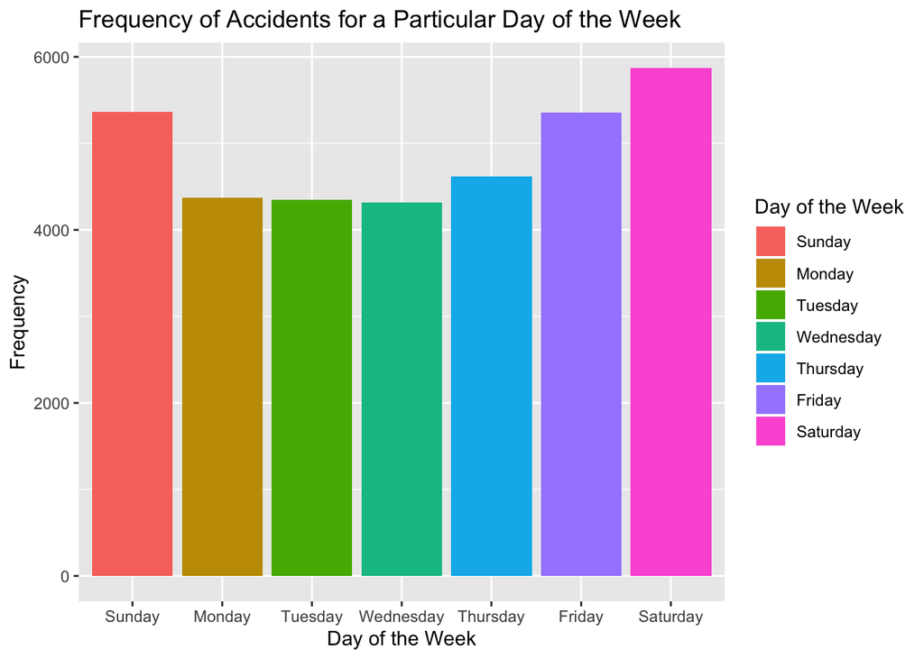

```r
days_freq %>%
  ggplot(aes(x = Var1, y = Freq, fill = Var1)) + geom_bar(stat="identity")+labs(x = "Day of the Week", y = "Frequency", title = "Frequency of Accidents for a Particular Day of the Week", fill = "Day of the Week")
```

2.) what time of the day do accidents happen (use variable HOUR)?

### Similar to question one, I followed the same method to determine which hour of the day did accidents most frequently occur. According to the 5 number summary of the frequencies, we can see that the median, mean and 3rd quartile are 1321, 1370 and 1760 respectively. Looking at our barchart and frequency table we can see that the hours: 16, 17, 18, 19, 20 and 21 had frequencies larger than the 3rd quartile. This makes sense because at these hours people are off work performing leisure activities. Their focus is less guarded and it is darker outside, this combination can lead to car accidents.

```r
hour_freq <- acc
hour_freq <- data.frame(table(hour_freq$HOUR))
hour_freq$Var1 <- recode(hour_freq$Var1, "99"="N/A")
summary(hour_freq$Freq)
```

```
##    Min. 1st Qu.  Median    Mean 3rd Qu.    Max.
##     262    1065    1321    1370    1760    2000
```

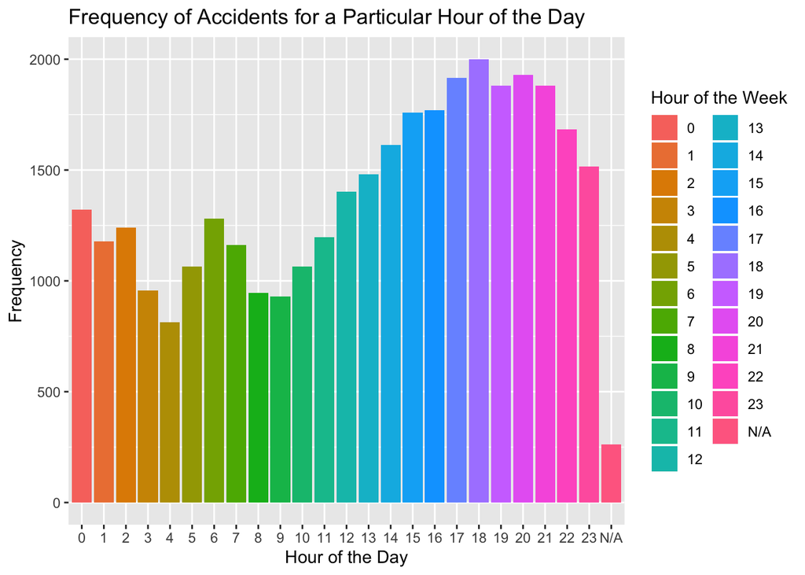

```r
hour_freq %>%
  ggplot(aes(x = Var1, y = Freq, fill = Var1)) + geom_bar(stat="identity")+labs(x = "Hour of the Day", y = "Frequency", title = "Frequency of Accidents for a Particular Hour of the Day", fill = "Hour of the Week")
```

3.) what is the number of accidents with at least one drunk driver (use variable DRUNK_DR)?

### The number of accidents with at least one drunk driver is 8769 accidents.

```r
dr_drive <- acc
dr_drive <- data.frame(table(dr_drive$DRUNK_DR))
num_dr_drive <- sum(dr_drive[2:4, 2])
num_dr_drive
```

```
## [1] 8769
```

4. In the person table, identify drivers (PER_TYP == 1, see FARS manual) and subset on them.

### To identify the drivers we select the rows which PER_TYP == 1. This subsets our dataset from 84921 rows to 52274 rows.

```r
drivers_only <- per
drivers_only <- drivers_only[which(drivers_only$PER_TYP == 1),]
drivers_only <- na.omit(drivers_only)
```

5. Join accident and person table (work out which variable(s) to use)

Variables to use (temp_acc):persons, city,Month,day, hour, TWAY_ID, LATITUDE, LONGGITUD, WEATHER,FATALS

Variables to use (temp_drive):Month,day, hour,sex, per_typ, age, drugs, County

```r
#nrow(acc) = 34247
temp_drive <- drivers_only %>%
  distinct(ST_CASE, .keep_all = TRUE)
#nrow(temp_drive) = 34157

# Find the differences in the two data sets.
differences <- setdiff(acc$ST_CASE, temp_drive$ST_CASE)
# length(differences) = 90

# remove values that are in the differences vector.
temp_acc <- acc
temp_acc <- temp_acc[ ! temp_acc$ST_CASE %in% differences, ]
# nrow(temp_acc) == nrow(temp_drive) is true.

# Extract certain columns
acc_col_extract <- temp_acc %>%
  select(PERSONS, CITY, MONTH, DAY, HOUR, TWAY_ID, LATITUDE, LONGITUD, WEATHER, FATALS, DAY_WEEK)
per_col_extract <- temp_drive %>%
  select(SEX, PER_TYP, AGE, DRUGS, COUNTY)
# merge the data frames.
joint_dat <- cbind(acc_col_extract, per_col_extract)
```

6. Tally the number of accidents by day of the week (DAY_WEEK), hour of the day (HOUR) and gender (SEX). Visualize the results.

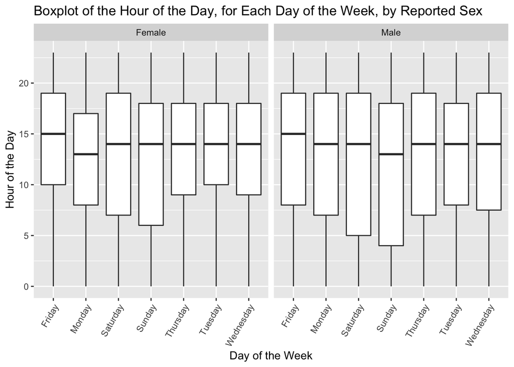

```r
joint_dat$DAY_WEEK <- recode(joint_dat$DAY_WEEK,
       "1"="Sunday",
       "2"="Monday",
       "3"="Tuesday",
       "4"="Wednesday",
       "5"="Thursday",
       "6"="Friday",
       "7"="Saturday")

joint_dat$SEX <- recode(joint_dat$SEX,
       "1"= "Male", "2" = "Female", "8" = "Not Reported", "9" = "Unknown")

joint_dat_day <- data.frame(table(joint_dat$DAY_WEEK))


joint_dat_hour <- data.frame(table(joint_dat$HOUR))


joint_dat_sex <- data.frame(table(joint_dat$SEX))

joint_box <- joint_dat
joint_box <- joint_box[!joint_box$HOUR==99,]
joint_box <- joint_box[!joint_box$SEX=="Not Reported",]
joint_box <- joint_box[!joint_box$SEX=="Unknown",]

### visualizing all of the data.
ggplot(joint_box) + geom_boxplot( aes(x = DAY_WEEK, y = HOUR )) + facet_wrap(~SEX)+ theme(axis.text.x = element_text(angle = 60, hjust = 1))+labs(x = "Day of the Week", y = "Hour of the Day", title = "Boxplot of the Hour of the Day, for Each Day of the Week, by Reported Sex")
```

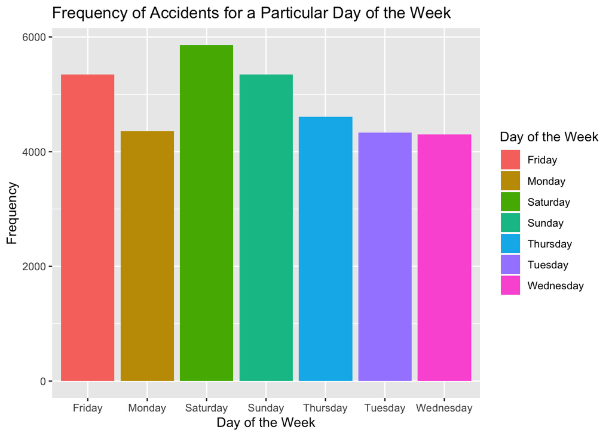

```r
### Bar charts to tally the number visually.
joint_dat_day %>%
  ggplot(aes(x = Var1, y = Freq, fill = Var1)) + geom_bar(stat="identity")+labs(x = "Day of the Week", y = "Frequency", title = "Frequency of Accidents for a Particular Day of the Week", fill = "Day of the Week")
```

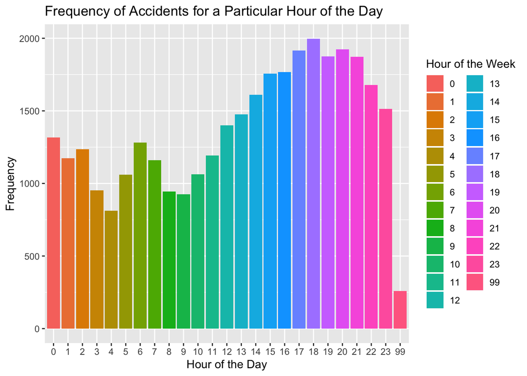

```r
joint_dat_hour %>%
  ggplot(aes(x = Var1, y = Freq, fill = Var1)) + geom_bar(stat="identity")+labs(x = "Hour of the Day", y = "Frequency", title = "Frequency of Accidents for a Particular Hour of the Day", fill = "Hour of the Week")
```

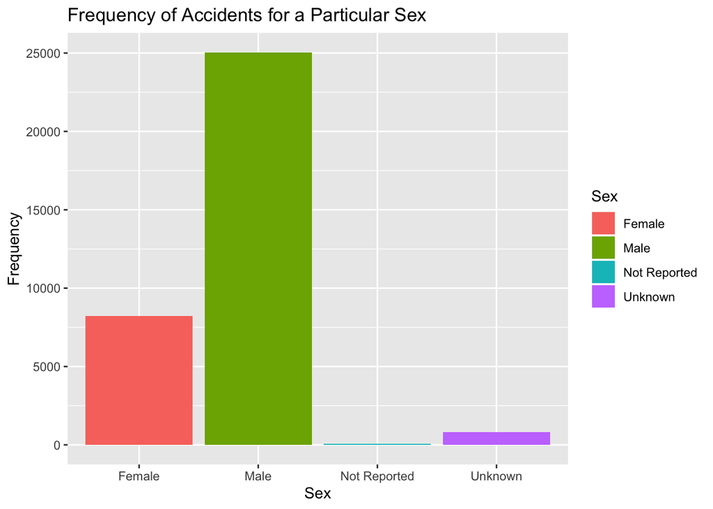

```r
joint_dat_sex %>%
  ggplot(aes(x = Var1, y = Freq, fill = Var1)) + geom_bar(stat="identity")+labs(x = "Sex", y = "Frequency", title = "Frequency of Accidents for a Particular Sex", fill = "Sex")
```

###use readxl::read_xlsx to read in the GLCs

```r
glc <- readxl::read_xlsx("FRPP GLC - United StatesFeb132020.xlsx")
```

### Tidy up the glc data.

```r
### rename
glc<- glc %>%
  rename(
    "STATE" = "State Code",
    "COUNTY" = "County Code"
  )

drops <- c("Country Code","Old City Name", "Date Record Added")
glc <- glc[ , !(names(glc) %in% drops)]


glc <- transform(glc, STATE = as.numeric(STATE),
               COUNTY = as.numeric(COUNTY))
```

# Another method to join the data. Just to see what we are working with.

```r
df <- glc %>%
  select('State.Name', STATE = 'STATE', COUNTY = 'County.Name', 'County.Name') %>%
  unique()
df$STATE <- as.integer(df$STATE)
df$COUNTY <- as.integer(df$STATE)


df1 <- df %>%
  select(STATE, COUNTY) %>%
  group_by(STATE, COUNTY) %>%
  summarize(total_accidents= n()) %>%
  left_join(glc, by = c('STATE', 'COUNTY'))

df2 <- map_data('county')

df2 <- df2 %>%
  mutate(`State Name` = region, `County Name` = subregion) %>%
  select(`State Name`, `County Name`, long, lat, group, order)

df1 <- df1 %>%
  full_join(df1, by = c('State.Name', 'County.Name'))
```

7/8. Now plot a choropleth map of accidents on a county level. Visualize the number of accidents in each county using a choropleth map. To do this, you need to join the accident data, GLCs, and appropriate map data.

### The county ID is accounted for by color. The abundance of dots, with their color corresponding to country ID, represents the number of accidents in a certain region.

### We found that we were able to gather the same information just by using the states map data and the accident data.

```r
# merge two data frames by STATE and COUNTY
temp_acc <- acc

merged <- merge(data.frame(temp_acc, row.names=NULL), data.frame(glc, row.names=NULL), by = 0, all = TRUE)[-1]
merged_complete <- na.omit(merged)

# graph
graph_dat <- merged_complete

# Get outline of US maps
states <- map_data("state")

# obtain only mainland state values
graph_dat <- graph_dat[!graph_dat$COUNTY.x==0,]
graph_dat <- graph_dat[!graph_dat$COUNTY.x==999,]
graph_dat <- graph_dat[!graph_dat$COUNTY.x==997,]
graph_dat <- graph_dat[!graph_dat$COUNTY.x==998,]
graph_dat<-graph_dat[graph_dat$LONGITUD < 0,]
graph_dat<-graph_dat[graph_dat$LONGITUD > -130,]
graph_dat<-graph_dat[graph_dat$LATITUDE < 50,]
```

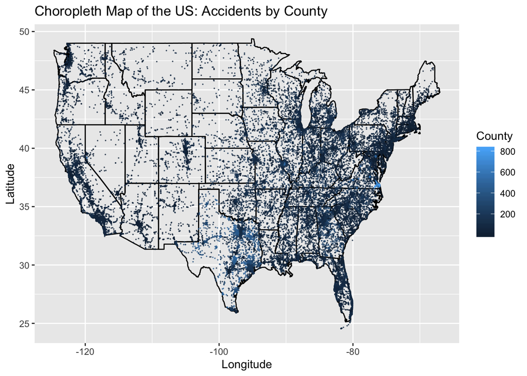

```r
states %>% ggplot(aes(x = long, y = lat)) +
  geom_path(aes(group = group))+geom_point(data = graph_dat, aes(x = LONGITUD, y = LATITUDE, color = COUNTY.x), alpha = 0.7, size = 0.02) +
  labs(x = "Longitude", y = "Latitude", title = "Choropleth Map of the US: Accidents by County", color = "County")
```

9. Can you find seasonal trends in accident occurrences in different states? Is summer or winter more dangerous? Why?

### Using the choropleth map we are able to visualize some seasonal trends in which accidents occur. As expected the winter months have the largest amount of accidents, especially along the coastlines of the northern lake states like Wisconsin and Michigan. This can be seen by the abundance of yellow points. But it is important to notice, that in the months building up to the winter (September and October) there are also a lot of points, as shown by light green. This shows that the build up to the winter produces a lot of accidents as well. But not to be overshadowed the summer months also show a large showing accident points in the congested areas like the east coast. This may be due to the driving culture and congested highways and speedways.